# World Happiness Report: Exploratory Data Analysis

chris gunderson

## Import Libraries

```r
library(tidyverse)
library(fs) # file system operations
library(janitor) # clean up file names
library(ggcorrplot) # correlations heatmap
```

## Explore files in our data directory

We have multiple files on the world health data that may have the same or similar variable names. It may be possible to later combine these datasets.

```r
# Specify data directory and print filenames

data_dir <- "data"

fs::dir_ls(data_dir)
```

```
## data/add-filename-prefix.py   data/world-happiness-2015.csv
## data/world-happiness-2016.csv data/world-happiness-2017.csv
## data/world-happiness-2018.csv data/world-happiness-2019.csv
```

Since we have a python script in the directory, we want to exclude this file for import.

```r
# exclude files that are not .csv

csv_files <- fs::dir_ls(data_dir, regexp = "\\.csv$")
csv_files # print csv file list
```

```
## data/world-happiness-2015.csv data/world-happiness-2016.csv
## data/world-happiness-2017.csv data/world-happiness-2018.csv
## data/world-happiness-2019.csv
```

## Import data

Since the most recent report is from 2019, I will examine this.

### 2019 World Happiness Report

Now, I test importing one of the .csv files and examining its general structure.

```r
# Import one .csv file and
whr_2019 <- readr::read_csv("data/world-happiness-2019.csv")

glimpse(whr_2019)
```

```
## Rows: 156
## Columns: 9
## $ `Overall rank`                 <dbl> 1, 2, 3, 4, 5, 6, 7, 8, 9, 10, 11, 12, …
## $ `Country or region`            <chr> "Finland", "Denmark", "Norway", "Icelan…
## $ Score                          <dbl> 7.769, 7.600, 7.554, 7.494, 7.488, 7.48…
## $ `GDP per capita`               <dbl> 1.340, 1.383, 1.488, 1.380, 1.396, 1.45…
## $ `Social support`               <dbl> 1.587, 1.573, 1.582, 1.624, 1.522, 1.52…
## $ `Healthy life expectancy`      <dbl> 0.986, 0.996, 1.028, 1.026, 0.999, 1.05…
## $ `Freedom to make life choices` <dbl> 0.596, 0.592, 0.603, 0.591, 0.557, 0.57…
## $ Generosity                     <dbl> 0.153, 0.252, 0.271, 0.354, 0.322, 0.26…
## $ `Perceptions of corruption`    <dbl> 0.393, 0.410, 0.341, 0.118, 0.298, 0.34…
```

### Clean up variable names

As shown above, many variable names have spaces. I’ll use the `janitor` package to clean up the variable names.

```r
# View data after cleaning variable names

whr_2019_clean <-
whr_2019 %>%
  janitor::clean_names() %>%
  glimpse()
```

```
## Rows: 156
## Columns: 9
## $ overall_rank                 <dbl> 1, 2, 3, 4, 5, 6, 7, 8, 9, 10, 11, 12, 13…
## $ country_or_region            <chr> "Finland", "Denmark", "Norway", "Iceland"…
## $ score                        <dbl> 7.769, 7.600, 7.554, 7.494, 7.488, 7.480,…
## $ gdp_per_capita               <dbl> 1.340, 1.383, 1.488, 1.380, 1.396, 1.452,…
## $ social_support               <dbl> 1.587, 1.573, 1.582, 1.624, 1.522, 1.526,…
## $ healthy_life_expectancy      <dbl> 0.986, 0.996, 1.028, 1.026, 0.999, 1.052,…
## $ freedom_to_make_life_choices <dbl> 0.596, 0.592, 0.603, 0.591, 0.557, 0.572,…
## $ generosity                   <dbl> 0.153, 0.252, 0.271, 0.354, 0.322, 0.263,…
## $ perceptions_of_corruption    <dbl> 0.393, 0.410, 0.341, 0.118, 0.298, 0.343,…
```

### Check for missing values

It is also important to check if there are any missing values across any of the variables. Below, we check this before doing exploratory data analysis.

```r
# Identify any missing values across variables
apply(whr_2019_clean, 2, anyNA)
```

```
##                 overall_rank            country_or_region
##                        FALSE                        FALSE
##                        score               gdp_per_capita
##                        FALSE                        FALSE
##               social_support      healthy_life_expectancy
##                        FALSE                        FALSE
## freedom_to_make_life_choices                   generosity
##                        FALSE                        FALSE
##    perceptions_of_corruption
##                        FALSE
```

### Summary Statistics across variables

1. **GDP per Capita**: `gdp_per_capita` The GDP per capita level of a country.
2. **Social Support**: `social_support` The impact of a supportive social circle, i.e., the positive impact of having relatives or friends.
3. **Healthy Life Expectancy**: `healthy_life_expectancy` The average life expectancy for healthy individuals.
4. **Freedom to Make Life Choices**: `freedom_to_make_life_choices` The positive impact of a population’s freedom of choice.
5. **Generosity**: `generosity` The population’s overall level of generosity.
6. **Perceptions of Corruption**: `perceptions_of_corruption` The level of trust in business and government.

```r
summary(whr_2019_clean)
```

```
##   overall_rank    country_or_region      score       gdp_per_capita
##  Min.   :  1.00   Length:156         Min.   :2.853   Min.   :0.0000
##  1st Qu.: 39.75   Class :character   1st Qu.:4.545   1st Qu.:0.6028
##  Median : 78.50   Mode  :character   Median :5.380   Median :0.9600
##  Mean   : 78.50                      Mean   :5.407   Mean   :0.9051
##  3rd Qu.:117.25                      3rd Qu.:6.184   3rd Qu.:1.2325
##  Max.   :156.00                      Max.   :7.769   Max.   :1.6840
##  social_support  healthy_life_expectancy freedom_to_make_life_choices
##  Min.   :0.000   Min.   :0.0000          Min.   :0.0000
##  1st Qu.:1.056   1st Qu.:0.5477          1st Qu.:0.3080
##  Median :1.272   Median :0.7890          Median :0.4170
##  Mean   :1.209   Mean   :0.7252          Mean   :0.3926
##  3rd Qu.:1.452   3rd Qu.:0.8818          3rd Qu.:0.5072
##  Max.   :1.624   Max.   :1.1410          Max.   :0.6310
##    generosity     perceptions_of_corruption
##  Min.   :0.0000   Min.   :0.0000
##  1st Qu.:0.1087   1st Qu.:0.0470
##  Median :0.1775   Median :0.0855
##  Mean   :0.1848   Mean   :0.1106
##  3rd Qu.:0.2482   3rd Qu.:0.1412
##  Max.   :0.5660   Max.   :0.4530
```

## Visualization

### Happiness score

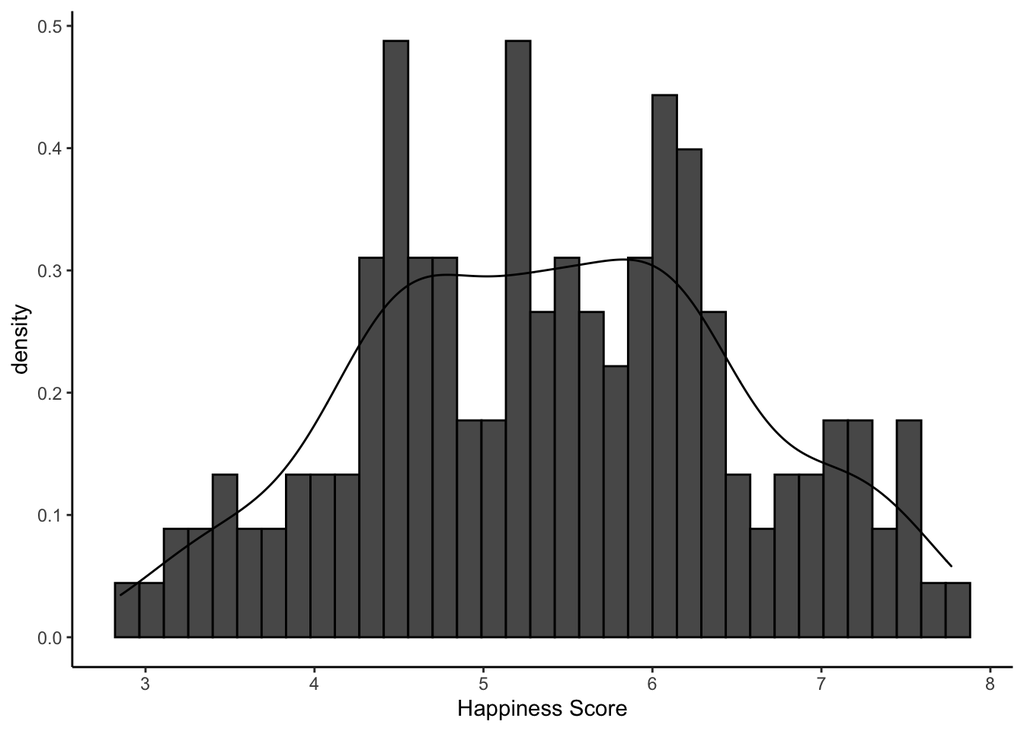

```r
ggplot(whr_2019_clean, aes(x = score)) +
  geom_histogram(aes(y = ..density..), bins = 35, color = "black") +
  geom_density() +
  labs(x = "Happiness Score") +
  theme_classic()
```

### The 10 most happy countries

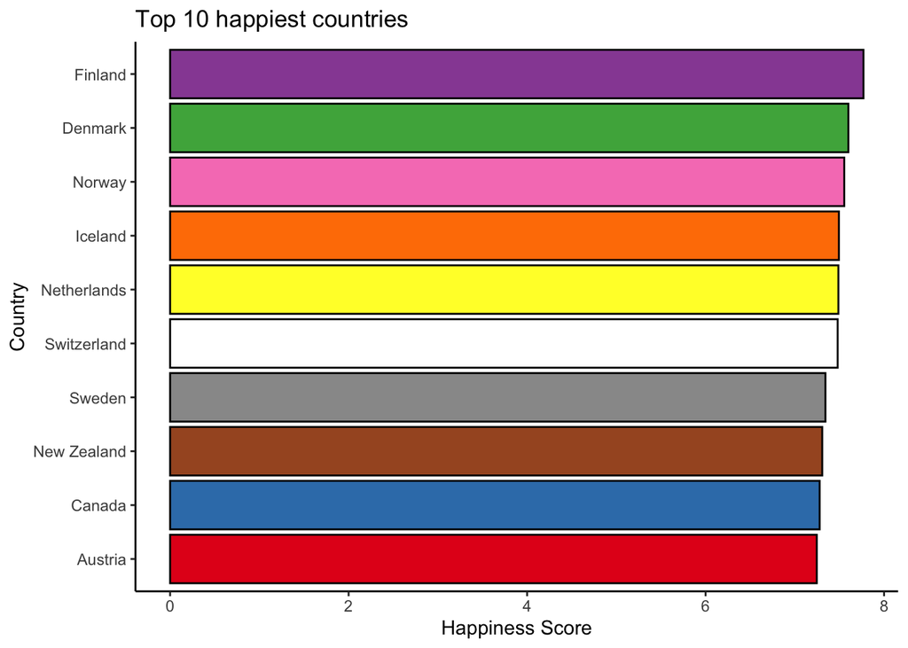

```r
# descriptive table

top10_happy <-
whr_2019_clean %>%
  arrange(desc(score)) %>%
  head(10) %>%
  select(overall_rank:score)

# barplot of top 5 happiest countries
top10_happy %>%
  ggplot(aes(x = score, y = reorder(country_or_region, score),
             fill = country_or_region)) +
  geom_bar(stat = "identity", color = "black") +
  scale_fill_brewer(palette = "Set1") +
  labs(title = "Top 10 happiest countries",
       x = "Happiness Score",
       y = "Country") +
  theme_classic() +
  theme(legend.position = "none")
```

### The 10 least happy countries

[figure not shown]

```r
# descriptive table

bottom10_happy <-
whr_2019_clean %>%
  arrange(score) %>%
  head(10) %>%
  select(overall_rank:score)

# barplot of 10 least happy countries
bottom10_happy %>%
  ggplot(aes(x = score, y = reorder(country_or_region, desc(score)),
             fill = country_or_region)) +
  geom_bar(stat = "identity", color = "black") +
  scale_fill_brewer(palette = "Set3") +
  labs(title = "The 5 least happy countries",
       x = "Happiness Score",
       y = "Country") +
  theme_classic() +
  theme(legend.position = "none")
```

## Relationship between happiness and other variables

First, we will explore a correlation heatmap to see which variables are most strongly related to happiness scores.

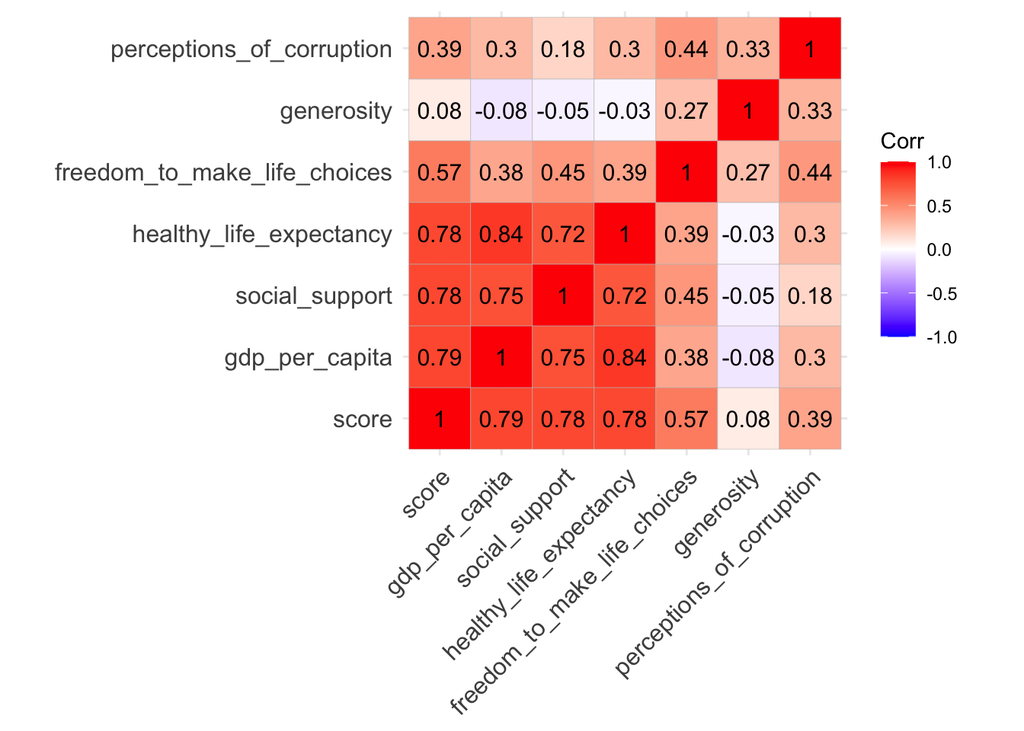

```r
# select the variables for correlation heatmap
corr_vars <- whr_2019_clean %>%
  select(score:perceptions_of_corruption)

ggcorrplot::ggcorrplot(cor(corr_vars), lab = TRUE)
```

The variables with the strongest relationship to happiness are GDP (.79), social support (.78), and healthy life expectancy (.78).

### Happiness and GDP, social support, and healthy life expectancy

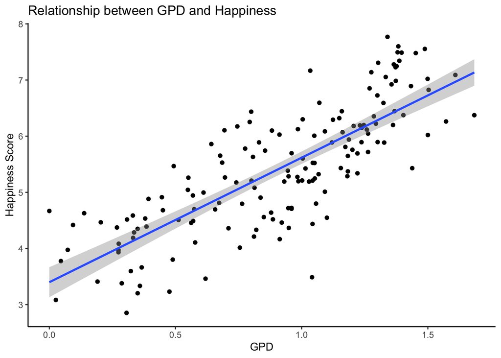

```r
# GDP

ggplot(whr_2019_clean, aes(x = gdp_per_capita,
                           y = score)) +
  geom_point() +
  geom_smooth(method = "lm") +
  labs(title = "Relationship between GPD and Happiness",
       x = "GPD",
       y = "Happiness Score") +
  theme_classic()
```

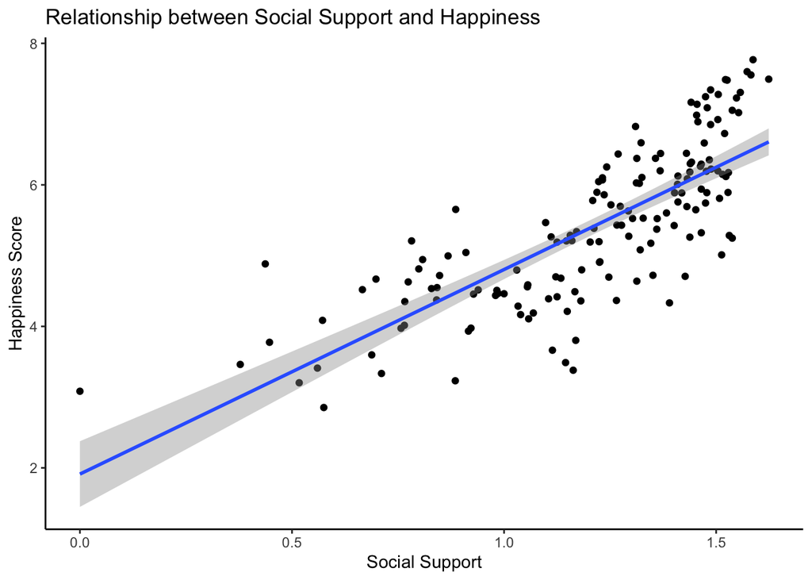

```r
# Social Support

ggplot(whr_2019_clean, aes(x = social_support,
                           y = score)) +
  geom_point() +
  geom_smooth(method = "lm") +
  labs(title = "Relationship between Social Support and Happiness",
       x = "Social Support",
       y = "Happiness Score") +
  theme_classic()
```

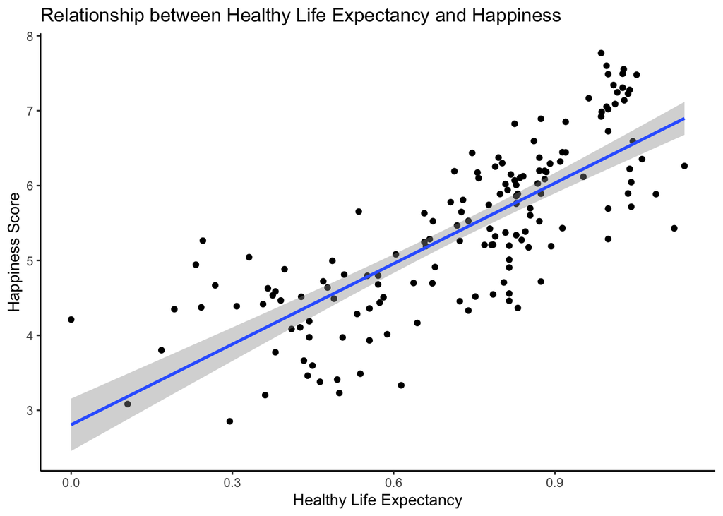

```r
# Healthy Life Expectancy

ggplot(whr_2019_clean, aes(x = healthy_life_expectancy,
                           y = score)) +
  geom_point() +
  geom_smooth(method = "lm") +
  labs(title = "Relationship between Healthy Life Expectancy and Happiness",
       x = "Healthy Life Expectancy",
       y = "Happiness Score") +
  theme_classic()
```